# Entrega 01 — Sistema de Alerta Temprana de Ejecución Presupuestaria

Diplomado en Ciencia de Datos para las Finanzas — Curso Finanzas en R (Proyecto del curso)

Renata Gómez

16 de septiembre 2026

# 1 Descripción de la solución

## 1.1 Contexto y problema de negocio

El Departamento de Finanzas de la Subsecretaría de Evaluación Social (SES), Ministerio de Desarrollo Social y Familia, genera **mensualmente** un informe de ejecución presupuestaria por línea de gasto (subtítulo/ítem), que registra el **Presupuesto Vigente**, el **Compromiso Acumulado** (recursos ya obligados vía contrato u orden de compra, aunque no necesariamente pagados) y el **Devengado Acumulado** (recursos efectivamente pagados o con obligación firme de pago) de cada línea.

Hoy, la identificación de qué líneas presupuestarias están **rezagadas** respecto del avance esperado para el mes del año en curso se hace **de forma manual**, debido a que un profesioanl del equipo revisa el Excel fila por fila. Este proceso es lento, depende de la disponibilidad de una persona específica, es propenso a error humano, y no deja un registro histórico sistemático de qué líneas se marcaron en riesgo cada mes ni de si ese riesgo se corrigió o empeoró en los meses siguientes.

*Fuente de datos: Informe de Ejecución Presupuestaria SES, julio 2026 — documento interno de gestión presupuestaria del Departamento de Finanzas, Subsecretaría de Evaluación Social.*

## 1.2 Qué soluciona

Un flujo reproducible en R que, a partir del informe mensual de ejecución presupuestaria:

1. Calcula automáticamente los indicadores de avance por línea (% Compromiso y % Devengado sobre el Presupuesto Vigente).
2. Clasifica cada línea como **“En Meta”** o **“Rezagada”** según el avance esperado para el mes del año en curso.
3. Deja una base para, en etapas posteriores del proyecto (Entregas 02 y 03), entrenar y documentar un modelo de clasificación, desplegarlo y monitorearlo en el tiempo — siguiendo el ciclo de vida (Collect → Clean → Train/Evaluate → Version → Deploy → Monitor) pedido en el curso.

No se trata de “el cálculo de un porcentaje”, sino de una solución de seguimiento continuo que reemplaza una revisión manual mensual por un proceso estandarizado y reproducible.

## 1.3 A quiénes impacta

- **Jefatura del Departamento de Finanzas:** puede priorizar qué líneas revisar antes del cierre del ejercicio presupuestario, en lugar de revisar manualmente la totalidad de las líneas cada mes.
- **Encargados de cada línea o programa** (por ejemplo, Remuneraciones, Modernización, encuestas y estudios): reciben una señal temprana de que su línea está rezagada, con tiempo para corregir antes de que se transforme en un problema de cierre de año.
- **Subsecretaría y nivel directivo superior:** obtienen visibilidad consolidada y estandarizada del estado de ejecución presupuestaria global, sin depender de que alguien arme manualmente un resumen cada mes. Esto lo revisa el Subsecretario y su gabinete.

## 1.4 Cómo se espera solucionar el problema

Se construirá un pipeline en R que:

- **Extrae** los datos directamente del Excel de ejecución presupuestaria mensual (mismo formato que se usa hoy internamente), evitando el traspaso manual de cifras.
- **Calcula** los indicadores de avance (% Compromiso, % Devengado) por línea presupuestaria.
- **Clasifica** cada línea aplicando un criterio de avance esperado según el mes del año (por ejemplo: a julio, mes 7 de 12, se espera un avance mínimo determinado; bajo ese umbral, la línea se marca “Rezagada”).
- En la Entrega 02, este criterio se formalizará como un **modelo de clasificación supervisado**, entrenado y evaluado con métricas relevantes (matriz de confusión, precisión, recall), y se documentará su ciclo de vida completo (versión, despliegue, monitoreo) en las Entregas 02 y 03.

## 1.5 Periodicidad

**Mensual**, alineada al ciclo real de generación del informe de ejecución presupuestaria de la Subsecretaría de Evaluación Social (el mismo corte que hoy se revisa manualmente cada mes).

## 1.6 Alcance

**Qué considera:**

- Datos reales de ejecución presupuestaria de la SES (Presupuesto Vigente, Compromiso Acumulado, Devengado Acumulado, por línea/subtítulo).
- Clasificación de líneas en riesgo de rezago de ejecución.
- Reproducibilidad completa en R (código versionado en GitHub, gestión de dependencias con `renv`).
- Documentación del ciclo de vida del modelo (entrenamiento, versión, despliegue, monitoreo).

**Qué no considera (fuera de alcance):**

- Integración automática en tiempo real con el sistema contable/presupuestario institucional del Estado — se trabaja sobre el reporte mensual ya exportado en Excel, no sobre una conexión en vivo.
- Decisiones de reasignación presupuestaria: la solución **alerta**, no decide ni ejecuta cambios de presupuesto — esa decisión sigue siendo de la Jefatura de Finanzas.
- Proyecciones de gasto futuro más allá del cierre del año presupuestario en curso.

# 2 Planificación del trabajo

## 2.1 Descriptor de fases

El proyecto se organiza en las 3 entregas que exige el curso, cada una en su propia carpeta del repositorio de GitHub:

[output not shown]

## 2.2 Carta Gantt

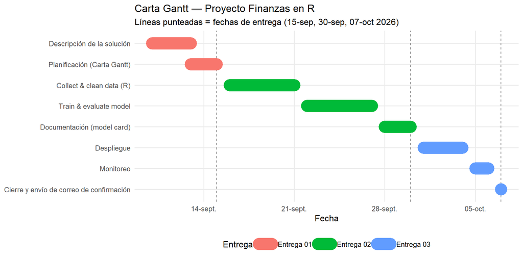

```r
library(ggplot2)

tareas <- data.frame(
  entrega = c("Entrega 01", "Entrega 01",
              "Entrega 02", "Entrega 02", "Entrega 02",
              "Entrega 03", "Entrega 03", "Entrega 03"),
  tarea = c("Descripción de la solución",
            "Planificación (Carta Gantt)",
            "Collect & clean data (R)",
            "Train & evaluate model",
            "Documentación (model card)",
            "Despliegue",
            "Monitoreo",
            "Cierre y envío de correo de confirmación"),
  inicio = as.Date(c("2026-09-10", "2026-09-13",
                      "2026-09-16", "2026-09-22", "2026-09-28",
                      "2026-10-01", "2026-10-05", "2026-10-07")),
  fin    = as.Date(c("2026-09-13", "2026-09-15",
                      "2026-09-21", "2026-09-27", "2026-09-30",
                      "2026-10-04", "2026-10-06", "2026-10-07"))
)

tareas$tarea <- factor(tareas$tarea, levels = rev(unique(tareas$tarea)))

fechas_entrega <- as.Date(c("2026-09-15", "2026-09-30", "2026-10-07"))

ggplot(tareas, aes(x = inicio, xend = fin, y = tarea, yend = tarea, color = entrega)) +
  geom_vline(xintercept = fechas_entrega, linetype = "dashed", color = "grey50", linewidth = 0.4) +
  geom_segment(linewidth = 8, lineend = "round") +
  labs(
    title = "Carta Gantt — Proyecto Finanzas en R",
    subtitle = "Líneas punteadas = fechas de entrega (15-sep, 30-sep, 07-oct 2026)",
    x = "Fecha",
    y = NULL,
    color = "Entrega"
  ) +
  scale_x_date(date_breaks = "1 week", date_labels = "%d-%b") +
  theme_minimal(base_size = 12) +
  theme(panel.grid.minor = element_blank(),
        legend.position = "bottom")
```